# 大数据经济学

### 时间处理

- 1.time python 包
- 2.datetime python 包
- 3.pandas.to_datetime

time.localtime(secs)

- 将时间戳转换为当前的 struct time 结构
- secs 如果没有提供，默认使用前时间 time.time()
- 得到当前时间戳 time.mktime(t)
- 将 struct time 转换为时间戳 time.strptime(string[, format])
- 将字符串时间转换为 struct time

time.strftime(format[, t])

- 将 struct time 转换为字符串
- t 默认为："%a %b %d %H:%M:%S %Y"

```python
import time

time.time()
time.localtime(secs) # 参数为时间戳秒数，为空则取当前时间
# output: time.struct_time(tm_year,tm_mon,tm_mday,tm_hour,tm_min,tm_sec,tm_wday,tm_yday,tm_isdst)

time.mktime(t) # 结构化时间转时间戳
# 定制函数字符串转时间戳
def s2timestamp(day):
    st=time.strptime(day, "%Y-%m-%d")
    return time.mktime(st)


time.strptime(string,'%Y-%m-%d %H:%M:%S') # 字符串转结构化
time.strftime('%Y-%m-%d %H:%M:%S', t) # 结构化转字符串
# 定制函数时间戳转字符串
def t2str(t):
    st=time.localtime(t)
    return time.strftime("%Y-%m-%d",st)
# 时间加法
s = 某date
t2s(s2t(s)+需加的天数*24*3600)
def add_day(day,num):
    smp1=time.mktime(time.strptime(day,"%Y-%m-%d"))
    smp2=smp1+24*3600*num
    day2s=time.localtime(smp2)
    return time.strftime("%Y-%m-%d",day2s)

# 时间减法
t1=s2t('2025-10-01')
t2=s2t('2022-01-01')
(t1-t2)/3600/24

def get_daysdiff(day1,day2):
    smp1=time.mktime(time.strptime(day1,"%Y-%m-%d"))
    smp2=time.mktime(time.strptime(day2,"%Y-%m-%d"))
    return int((smp2-smp1)/3600/24)

# 提取年份
def to_yearmonth(x):
    t=time.strptime(x,'%b-%y') #原本不合规的时间字符串长什么样
    y=time.strftime("%Y",t)
    m=time.strftime("%m",t)
    s = y+m
    return s # 只要年份和月份就单独输出
df['Y']=df['month'].apply(to_y)

# 提取week
def get_week(day): # time struct 中的 tm_day中的0表示星期一
    return time.strptime(day,"%Y-%m-%d").tm_wday+1
```

```python
%z  Time zone offset from UTC.
%a  Sun
%A  Sunday
%b  Oct
%B  October
%c  Locale's appropriate date and time representation.
%I  12小时制搭配%p
%p  Locale's equivalent of either AM or PM.
%W  周数，星期一为始 %Y_%W
%j  一年中的第几天
```

```python
# datetime
def add_day(day, num):
    """
    添加指定天数到给定日期
    :param day: str, 日期字符串，格式为 "%Y-%m-%d"
    :param num: int, 需要添加的天数
    :return: str, 新的日期字符串
    """
    date_obj = datetime.strptime(day, "%Y-%m-%d")
    new_date = date_obj + timedelta(days=num)
    return new_date.strftime("%Y-%m-%d")


def get_week(day):
    """
    获取给定日期的星期几
    :param day: str, 日期字符串，格式为 "%Y-%m-%d"
    :return: int, 星期几（1-7）
    """
    date_obj = datetime.strptime(day, "%Y-%m-%d")
    return date_obj.weekday() + 1

def get_week_start_end(day):
    """
    获取给定日期所在周的开始日和结束日
    :param day: str, 日期字符串，格式为 "%Y-%m-%d"
    :return: tuple, (开始日, 结束日)
    """
    date_obj = datetime.strptime(day, "%Y-%m-%d")
    start_of_week = date_obj - timedelta(days=date_obj.weekday())
    end_of_week = start_of_week + timedelta(days=6)
    return start_of_week.strftime("%Y-%m-%d"), end_of_week.strftime("%Y-%m-%d")
```

```python
# pandas
df['date'] = pd.to_datetime(df['date'],format='') #字符串转换为日期格式
df['days_interval'] = df['date'].diff().dt.days  # 计算相邻日期的天数差
```

### 缺失值处理

1. 向前填充法 :df.ffill()
2. 向后填充法 :df.bfill()
3. 线性插值法 : 线性插入新值
4. 二次插值法 : 而此项插入新值
5. 最近邻均值法 : 对左右邻居求平均
6. 季节均值法 : 取之前同季的均值

```python
# 缺失值查询
df.isnull()
df['col1'].isnull()
df.isnull.sum() #axis=0/1,0列1行

# 筛选有缺失值的行
df.loc[df.isnull().any(1)]
df.loc[~(df.isnull().any(1))] #取反

# 筛选有缺失值的列
df.loc[:,df.isnull().any()]

# 补
df.fillna(0)
df.fillna(method = 'ffill')#行数据向下填充
df.fillna(method = 'ffill',axis=1)#列数据向右填充
DataFrame.interpolate(method='linear'/'pad'/'time'/'nearest'/'cubic'/, axis=0, limit=None, inplace=False, limit_direction=None, limit_area=None, downcast=None, **kwargs)
```

### 随机数

```python
import random

## 基本随机数生成
random.random() #生成一个 [0.0, 1.0) 范围内的随机浮点数。
random.uniform(a, b)#生成一个 [a, b] 或 (a, b) 范围内的随机浮点数，包括边界。
random.randint(a, b)#生成一个 [a, b] 范围内的随机整数，包括边界。
random.randrange(start, stop[, step])#生成一个从 start 开始，到 stop 结束（不包括 stop），步长为 step 的随机整数。
random.choice(seq)# 从非空序列 seq 中随机选择一个元素。
random.choices(population, weights=None/cum_weights=None, k=1) #从 population 序列中随机选择 k 个元素，指定权重。
random.sample(population, k)#从 population 序列中随机选择 k 个不重复的元素。

## 序列操作
random.shuffle(x[, random])#就地打乱可变序列 x 的顺序。
random.permutation(x)#返回一个新的序列，包含 x 中所有元素的随机排列。

## 分布相关的随机数
random.paretovariate(alpha)#alpha=1.5 二八分布帕累托
random.gauss(mu, sigma)#生成一个符合均值为 mu，标准差为 sigma 的高斯分布（正态分布）的随机浮点数。
random.expovariate(lambd)#生成一个符合指数分布的随机浮点数，lambd 是速率参数。
random.lognormvariate(mu, sigma)#生成一个符合对数正态分布的随机浮点数。
random.poissonvariate(mu)#生成一个符合泊松分布的随机整数。
random.triangular(low, high=None, mode=None)#生成一个符合三角形分布的随机浮点数，范围在 [low, high] 之间，mode 指定峰值位置。

## 种子设置
random.seed()
random.getstate()#返回当前随机数生成器的状态。
random.setstate(state)#设置随机数生成器的状态为之前保存的状态。

## 其他实用工具
random.getrandbits(k) #生成一个 k 位的随机整数。
random.randbytes(n) #生成一个长度为 n 的随机字节串
```

## Economics

### 经济实验方法：更接近自然科学

- 可控性 : 可在实验室中排除研究不关心的因素 ; 发现真正的因果关系
- 可重复性 : 实验可以在全世界范围内重复

### 基尼系数

```python
# 1.公式法
def gini(L):
    s1=0
    s2=0
    for i in L:
        s2 += 2*len(L)*i #分母
        for j in L:
            s1 += abs(i-j) #分子 绝对值
    return s1/s2
L=[]
for i in df.index:
    L=L+[ df.loc[i,'income'] for j in range(int(df.loc[i,'people']/10000))]
gini(L)

#2.洛伦兹曲线（见画图）

s=0 #面积B（洛伦兹曲线内）
for i in df.index[1:]:
    people1=df.loc[i-1,'洛伦茨曲线'] #梯形的下底
    people2=df.loc[i,'洛伦茨曲线'] #梯形的上底
    people_ratio=df.loc[i,'people_ratio']
    s+=(people1+people2)*people_ratio*0.5
Gini=round((100*100*0.5-s)/(100*100*0.5),2)
Gini
```

### 股票相关

1. 夏普比率是诺奖获得者 Sharpe(1966) 开发的一种基金绩效评价标准。它通常用来衡量一项投资（如证券或投资组合）与无风险资产相比，在调整风险后的表现，其定义为投资回报与无风险回报之间的差额，除以投资回报的标准差，代表投资者每增加一个风险单位所获得的额外回报。

- 夏普比率 <0 时，资产表现还不如无风险利率，按大小排序没有意义
- 夏普比率 =0 时，资产平均净值和无风险利率一样，但承担了额外的风险
- 0< 夏普比率 <1，资产波动风险大于收益率。
- 夏普比率 =1，资产波动风险等于收益率，即投资风险每增加 1%, 预期收益也将增加 1%。
- 夏普比率 >1，资产波动风险小于收益。
- 夏普比率越高，那么就说明该资产每单位风险能够获得的风险回报也越高。

$$SharpeRatio= \frac{E(R_p)-R_f}{\sigma_p}$$

2. 单因子模型（见案例）

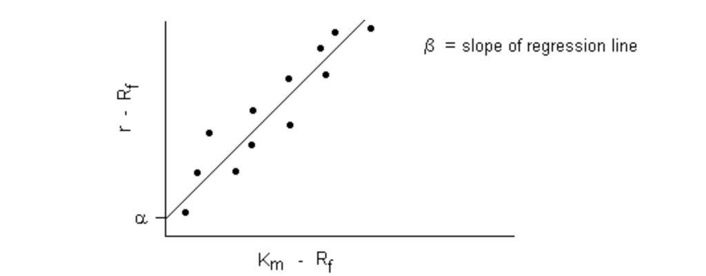

$$ r - R_f = \alpha + \beta ( K_m - R_f ) $$

3. 珐玛三因子模型（见案例） 法玛三因子模型（Fama-French Three-Factor Model）是一种资产定价模型（Capital Asset Pricing Model，CAPM）的扩展，用于解释股票回报的变异性。该模型由2013年诺奖获得者尤金·法玛（Eugene Fama）和肯尼斯·法rench（Kenneth French）于1992年提出。

- 三因子模型中的三因子分别指市场风险因子、市值因子和价值因子 , 这三个因子被认为是影响股票回报的重要因素。
  - 市场风险因子指的是股票市场整体的风险，一般用大盘指数体现
  - 市值因子是指公司的市值大小，根据市值效应（size effect，小市值公司和大市值公司收益率存在显著差异）
  - 价值因子是指公司的估值水平，根据价值效应（Value effect，低市净率的公司和高市净率公司，其收益率存在显著差异）

$$ R_i - R_f = \alpha_t + \beta(MKT_i) +\gamma(SMB_i) + \lambda(HML_i) + \xi_i $$

```
   $R_i$表示股票i的预期回报
   $R_f$表示无风险收益率（当时间较短不变时，可与$\alpha_t$合并
   $\beta$表示股票i的市场风险系数
   $\gamma$表示股票i的市值因子系数
   $\lambda$表示股票i的价值因子系数
   $MKT$表示市场风险因子的回报率
   $SMB$表示市值因子的超额回报
   $HML$表示价值因子的超额回报
```

- 通过考虑市值和价值因子，法玛三因子模型可以更好地解释股票回报的变异性。该模型被广泛应用于投资组合管理、风险管理和资产定价等领域。 在此基础上，Carhart的四因子增加了动量因子（一直涨的和一直跌的股票收益率的差异），Fama五因子模型增加了盈利因子（净资产收益率）和投资因子（资产增长率）。一些扎根中国的研究Liu等（2019)认为，价值因子在中国应该采用市盈率。

4. 事件研究法（ESM）（见案例）

事件研究法（Event Study Method）用于评估某一事件的发生或信息的发布，是否会改变投资人的决策，进而影响股票价格或交易量的变化。事件研究法应用于金融领域，借助金融市场数据分析某一特定经济事件对该公司价值或市场产生的影响，即是否产生异常收益（Abnormal Returns）。其理论基础在于有效市场假说：如果市场是有效的，那么此事件的影响会迅速反映到资产的价格上。

```python
#夏普
for code in 个股夏普率.index:
    df12=df11[df11['证券代码']==code]
    个股夏普率.loc[code,'夏普率']=(df12['考虑现金红利再投资的日个股回报率'].mean()
                           *交易日数-0.015)/(df12['考虑现金红利再投资的日个股回报率'].std()
                                        *交易日数**0.5) #每年242个交易日

#计算多年涨幅
years=sorted(list(set(df["year"])))
for y in years:
    df0=df[df["year"]==y].sort_values("trade_date")
    mul=1
    for i in df0.index:
        mul=mul*(df0.loc[i,"pct_chg"]+100)/100
    df1.loc[df1.shape[0]+1]={"年份":y,"涨幅":mul*100-100}

#按照涨幅复权价格
df1['price']=(df1['pct_chg']/100+1).cumprod()

#360日移动平均线
df1['360days_avg']=df1['price'].rolling(360,min_periods=10).mean() #对时间序列数据进行快速的移动平均计算
df1.plot(y=['price','360days_avg'])
```

```python
js['市值']= js['总股数'] * js['日收盘价']
```

### 费雪方程式

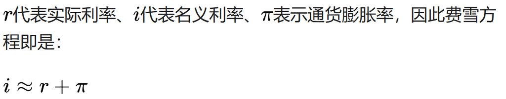

```python
df_demand["demand_nominal"]=df_demand["demand_reali"]+(100*inlfation-100)
```

### 统计

```python
china["名义增长率"]=china["地区生产总值"].pct_change()*100
china["实际增长率"]=china["地区生产总值指数(上年＝100)"]-100
```

```python
#同比环比
#pct_change(12) 表示相对于12个月前的变化，计算同比；默认计算环比变化
df["M0环比"]=df["m0"].pct_change()
df["M0同比"]=df["m0"].pct_change(12)

#用环比算环比指数
for i in df2.index:
    if i==0:
        df2.loc[i,'房价100指数']=(df2.loc[i,'房价100环比']+100)/100
    else:
        df2.loc[i,'房价100指数']=(100+df2.loc[i,'房价100环比'])*df2.loc[i-1,'房价100指数']/100
```

### 时间序列

长期趋势时间序列

- 客观现象在一个相当长的时间内所呈现出来的持续性增加或减少的一种趋向和状态，如近 40 年来的经济增长

循环变动时间序列

- 循环变动是时间序列中的一种更长期的周期性波动，通常与经济和商业周期有关。循环性波动通常跨越数年，而不仅仅是每年。这种波动可能受到经济周期、投资周期、产业周期等因素的影响。循环性变动通常不像季节性变动那样具有明确的、规则的周期性，而是在更大的时间尺度上发生。

季节变动时间序列

- 季节变动是时间序列数据中具有明显的重复和周期性模式的变化。这种变化通常是由季节性因素引起的，如季节性销售波动、天气季节变化等。季节性模式通常是在一年内或更短时间内的周期性变化。例如，零售行业可能会在假日季节（如双 11 购物季节）期间经历销售增长，而冰箱、空调等冷却设备销售可能在夏季季节增加。季节变动通常是周期性的，因此可以在特定时间点或季节中预期。

其他周期性时间序列

- 其他周期性波动可能由不同的因素引起，例如每周的工作日和周末效应、特定行业的生产周期、定期的社会活动等。这些波动在时间序列分析中通常被视为特定周期内的变动，并且可能需要单独建模和处理。

非平稳时间序列

- 上述序列或者上述序列的组合称为非平稳时间序列，其统计性质在时间上发生变化。

平稳时间序列

- 平稳时间序列的统计性质在时间上保持不变，即没有趋势、循环、季节性或其他周期性变化，数据随机进行波动，是许多时间序列分析方法的基础。

无长期趋势，用同期平均消除干扰

- 如果在序列图中，没有发现时间序列包含长期趋势，则直接利用原序列进行同期平均和总平均，消除不规则变动，计算出季节指数。

有长期趋势，分离趋势和季节

- 计算每个周期内的平均值，以得到季节性成分
- 通过计算趋势线或移动平均线来估计时间序列的趋势成分
- 使用趋势 - 季节性成分去除后得到一年以上的明显波动，再分离循环成分
- 计算残差 - 无法由趋势、季节性、循环性和已知成分解释的时间序列的剩余部分

加法分解时间序列

- Value = 趋势 + 季节 + Error
- 如果时间序列的趋势是线性的，即趋势成分以固定的增长率或绝对增量变化，通常使用加法分解更合适
- 时间序列数据包含零值或接近零的值，可能更适合使用加法分解，以避免出现零除法错误

乘法分解时间序列 :

- Value = 趋势 x 季节 x Error
- 如果趋势是非线性的，特别是随时间增长率增加或减小，可能需要考虑使用乘法分解
- 如果数据始终为正且无零值，可以考虑使用乘法分解。

```python
#季节趋势
import statsmodels.tsa.seasonal as sea
mul=sea.seasonal_decompose(df3['m0'], model='multiplicative', extrapolate_trend='freq')
add = sea.seasonal_decompose(df3['m0'], model='additive', extrapolate_trend='freq')
```

### ARIMA 模型

ARIMA 模型（自回归积分滑动平均模型，Autoregressive Integrated Moving Average）是一种常用的时间序列预测模型，特别适用于对单变量非平稳时间序列的建模和预测。ARIMA 模型由三个主要部分组成：自回归 (AR)、差分 (I)、滑动平均 (MA)，其目的是通过捕捉时间序列中的趋势、周期性及随机波动来生成预测。

1. 自回归 (AR) 部分 $$Y_t = \phi_1 Y_{t-1} + \phi_2 Y_{t-2} + \dots + \phi_p Y_{t-p} + \epsilon_t$$
2. 差分 (I) 部分 $$Y'_t = Y_t - Y_{t-1}$$
3. 滑动平均 (MA) 部分 $$Y_t = \epsilon_t + \theta_1 \epsilon_{t-1} + \theta_2 \epsilon_{t-2} + \dots + \theta_q \epsilon_{t-q}$$
4. ARIMA 模型的形式 ARIMA(𝑝,𝑑,𝑞)，参数分别为：
- p 自回归阶数（前多少个时间点的值用于预测当前值）
- q 差分阶数（用于使时间序列平稳化）
- q 滑动平均阶数（多少个过去的误差项用于预测当前值）。
- ARIMA(1,1,1) 为 $$Y_t = \phi_1 Y_{t-1} + \epsilon_t + \theta_1 \epsilon_{t-1}$$

### pmdarima 模块

- pmdarima 是一个基于 Python 的时间序列建模库，专门用于自动化 ARIMA 模型的构建和优化。
- 它可以在不需要手动调参的情况下快速搭建合适的时间序列预测模型。

```python
#pmdarima 自动搜索 ARIMA 模型的最佳参数组合
from pmdarima import auto_arima # 需要将numpy降级 pip3 install "numpy<2"
import pandas as pd
import time
model = auto_arima(df['m0'][:279],seasonal=True, m=12, trace=True,error_action="ignore")
forecasts = model.predict(4)#预测值
df['m0'][279:]#实际值
```

### Benford

- Benford's Law（本福德定律）是一种数学现象，它描述了在许多自然数据集中，数字 1 出现的概率明显高于其他数字（2、3、4、5、6、7、8、9）的概率。具体来说，根据 Benford's Law，数字 1 在数据集的首位出现的概率约为 30.1%，而数字 9 出现在首位的概率仅为 4.6% 左右，其他数字的概率依次递减。
- 这个现象最初由美国天文学家 Simon Newcomb 于 1881 年提出，后来由数学家 Frank Benford 于 1938 年进行了详细研究，因此得名 Benford's Law。这个定律的应用领域相当广泛，包括会计、审计、数据分析、金融领域、选举投票数据等各种领域。
- Benford's Law 的实际应用包括检测金融舞弊、分析选举投票数据的真实性、审计财务报表、识别假票据等。当数据集的分布不符合 Benford's Law 时，可能表明数据存在问题，需要进一步的调查和审查。这个法则在数字分布分析中具有重要的统计学和实际应用价值。
- 当数字 $d \in \{1,2,3,4,5,6,7,8,9\}$, 满足以下公式 $$ P(d)=log_{10}(d+1)-log_{10}(d)=log_{10}(\frac{d+1}{d}=log_{10}(1+\frac{1}{d}) $$

```python
import numpy as np
benford= np.log10(1 + 1 / np.arange(1, 10))
```

### 截面数据

截面数据（cross-section data）是指在同一时间（时期或时点）截面上反映一个总体的一批（或全部）个体的同一特征变量的观测值，是样本数据中的常见类型之一。 横截面数据不要求统计对象及其范围相同，但要求统计的时间相同。 常见截面数据:问卷调查数据（单次）;普查数据（单次）

不同的变量之间可以用不同单位来度量。如果出现度量的数值普遍过大或过小，会造成数据难以对比，回归系数不显著等问题。这时，可以采取去量纲处理。

```python
#离差标准化
import pandas as pd
df=pd.DataFrame([1,9,1,2,2,3,4,5,6,500],columns=["data"])
x_max = df['data'].max()
x_min = df['data'].min()
df['离差标准化'] = (df['data'] - x_min) / (x_max - x_min)

#标准差标准化，标准差为1
x_mean = df['data'].mean()
x_std = df['data'].std()
df['标准差标准化'] = (df['data'] - x_mean) / x_std
df['变量中心化'] = (df['data'] - x_mean)

#小数定标标准化
import numpy as np
k_max = abs(df['data']).max()
k = np.ceil(np.log10(k_max))
df['小数定标标准化'] = df['data'] / 10 ** k

#取对数
df['取对数'] = df['data'].apply(np.log)
df['取对数+1']=df['data'].apply(lambda x:np.log10(x+1))

#取变量排序值
df["排序"]=df['data'].rank(method='average')
```

```python
df.corr()
df.describe()

#多重共线性检验
X=df1[["除被解释变量外的变量列"]].copy()
X["常数项"]=1
vif=pd.DataFrame()
vif["features"] = X.columns
vif["vif factor"]=[statsmodels.stats.outliers_influence.variance_inflation_factor(X.values,i) for i in range(X.shape[1])]
vif
#=1没有多重共线性。1-5表示存在中度多重共线性；大于5表示存在严重的多重共线性。
```

### 简单回归

直接关系 调节关系 中介关系

因果关系

```
1. 排除结果发生在原因之前的情形
2. 排除原因和结果之间的偶然性
3. 排除第三个变量的影响
4. 排除逆向因果关系
```

相关关系

工具变量法

- 需要排除潜在的第三个变量
- 需要排除逆向因果
- 工具变量需满足
  - 工具变量对原因有影响
  - 工具变量对结果没有影响
  - 不存在第四个变量同时影响结果和工具变量

```python
import statsmodels.formula.api as smf
from linearmodels.panel import PanelOLS
from linearmodels import RandomEffects
import statsmodels as sm

#直接关系
results = smf.ols('Y  ~  X1 +  X2', data=df).fit()
print(results.summary())
results.params
results.resid
results.pvalues
results.rsquared
#OLS法二
exog_vars =['X1','X2']
exog = df[exog_vars].copy()
exog['常数项']=1
mod = PanelOLS(df['Y'], exog)
ols_res = mod.fit()

#调节关系
df=df.copy()
df['price1']=df['price']-df['price'].mean()
df['m_quanqiugou1']=df['m_quanqiugou']-df['m_quanqiugou'].mean()
df['price_quanqiu']=df['price1']*df['m_quanqiugou1'] #交叉项
results = smf.ols('Y  ~  price1 + m_quanqiugou1 + price_quanqiu ', data=df).fit()

#随机效应
mod = RandomEffects(df['Y'], exog)
re_res=mod.fit()

#固定效应
mod = PanelOLS(df['Y'], exog,entity_effects=True)
fe_res = mod.fit()

#2SLS
reg4 = smf.ols('产权保护指数89_95  ~   居民死亡率对数 ', data=df7).fit()
df7['预测产权保护指数4'] = reg4.predict()
reg7 = smf.ols('人均GDP95对数  ~   预测产权保护指数4 ', data=df7).fit()
```

### 面板

1、 OLS 回归 pooled model

所有的组都相同。即同一个方程 ，截距项和斜率项都相同。 假设所有个体或组之间没有差异，所有的观测值都来自同一个总体。 适用于当数据中不存在组间异质性的情况。

$y_{it}=c+bx_{it}+\varepsilon_{it} \qquad c 与 b 都是常数 $

2、固定效应模型 fixed-effect model

$y_{it}=c+a_i+bx_{it}+\varepsilon_{it} \qquad cov(c,x_{it})\neq0$

固定效应方程隐含着跨组差异可以用常数项的不同刻画。每个 $a_i$，是每个个体或组特有的常数项，被视为未知的待估参数。$x_{it}$ 中任何不随时间推移而变化的变量都会模拟因个体而已的常数项。

适用于当不同个体或组之间存在系统性差异，并且这些差异与解释变量相关时。所有不随时间变化的变量都会被固定效应吸收，因此无法估计这些变量的影响。

3、随机效应模型 random-effects model

$y_{it}=a+u_i+bx_{it}+\varepsilon_{it} \qquad cov(a+u_i,x_{it})=0$

在随机效应模型中，分组的差异不再通过每组单独的常数项来刻画，而是通过引入一个随机变量来反映。这意味着不同组之间的差异不是固定的常数，而是被视为随机的、从某个总体分布中抽取的。

$a$ 是一个常数项，是不可观察差异性的均值，表示每个个体或组的随机偏差，假定从某个分布中抽取。$u_i$ 为第 $i$ 个观察的随机差异性，不随时间变化。

适用于当不同个体或组之间的差异可以视为随机的、独立于解释变量时。

相比固定效应模型，随机效应模型更有效率，因为它利用了更多的信息，但需要满足随机效应假设。

4、混合效应模型

$y_{ij} = \beta_0 + \beta_1 x_{ij} + u_{0j} + u_{1j} x_{ij} + \varepsilon_{ij}$

- $ y_{ij} $: 第 $ j $ 组中第 $ i $ 个观测值的因变量。
- $ \beta_0 $: 固定效应部分的截距项，即所有组共享的平均截距。
- $ \beta_1 $: 固定效应部分的斜率项，即所有组共享的解释变量 $ x_{ij} $ 对因变量的平均影响。
- $ x_{ij} $: 第 $ j $ 组中第 $ i $ 个观测值的解释变量。
- $ u_{0j} $: 随机效应部分的截距项的偏差，表示组 $ j $ 相对于整体截距 $ \beta_0 $ 的随机偏离。
- $ u_{1j} $: 随机效应部分的斜率项的偏差，表示组 $ j $ 的斜率相对于整体斜率 $ \beta_1 $ 的随机偏离。
- $ \varepsilon_{ij} $: 误差项，表示个体 $ i $ 在组 $ j $ 中的观测误差，通常假定为正态分布， $ \varepsilon_{ij} \sim N(0, \sigma^2) $。

适用于当数据同时包含固定效应和随机效应时，即既有跨组的系统性差异，也有组内随机波动。 允许估计组间差异的同时，也考虑了组内的随机变化，提供了更灵活的建模方式。

举例

1. OLS 回归（Pooled Model）

研究全国范围内房价与人均收入的关系。

- **数据**：收集了多个城市的数据，每个城市有若干年份的房价和人均收入。
- **假设**：所有城市的房价与人均收入之间的关系是相同的，没有考虑城市间的差异。
- **公式**：$y_{it} = c + b x_{it} + \varepsilon_{it}$，其中 $y_{it}$ 是第 $i$ 个城市第 $t$ 年的房价，$x_{it}$ 是第 $i$ 个城市第 $t$ 年的人均收入。
- 假设所有城市都遵循同一个线性关系，即房价对人均收入的反应相同。
- 如果实际上城市间存在显著差异（如一线城市和三四线城市的房价变化规律不同），OLS 回归可能会产生偏差。
2. 固定效应模型（Fixed-Effect Model）

研究不同公司在同一时间段内的利润率与广告支出的关系。

- **数据**：收集了多家公司的年度财务数据，包括利润率和广告支出。
- **假设**：每家公司都有其独特的特征（如公司文化、管理风格等），这些特征会影响利润率，且这些特征不随时间变化。
- **公式**：$y_{it} = c + a_i + b x_{it} + \varepsilon_{it}$，其中 $a_i$ 是第 $i$ 家公司的固定效应。
- 每家公司的固定效应 $a_i$ 反映了该公司特有的影响因素。
- 例如，某些公司可能因为品牌优势或市场地位而有更高的利润率，即使广告支出相同。
- 固定效应模型可以控制这些未观察到的公司特定因素，从而更准确地估计广告支出对利润率的影响。
3. 随机效应模型（Random-Effects Model）

研究不同医院的患者满意度与等待时间的关系。

- **数据**：收集了多个医院的患者调查数据，包括患者的满意度评分和等待时间。
- **假设**：不同医院之间存在随机差异，这些差异可以视为从某个总体分布中抽取，并且这些差异与等待时间无关。
- **公式**：$y_{it} = a + u_i + b x_{it} + \varepsilon_{it}$，其中 $u_i$ 是第 $i$ 家医院的随机效应。
- 随机效应 $u_i$ 反映了不同医院之间的随机差异，如管理水平、设施条件等。
- 如果这些差异与等待时间无关，则可以使用随机效应模型来提高估计效率。
- 例如，某些医院可能因为地理位置或资源分配的不同而导致患者满意度的差异，但这些差异并不直接影响等待时间。
4. 混合效应模型（Mixed-Effects Model）

研究不同学校的学生考试成绩与课外辅导时间的关系。

- **数据**：收集了多所学校的学生成绩数据，包括学生的考试成绩和课外辅导时间。
- **假设**：不同学校之间存在系统性差异（如师资力量、教学资源），同时在同一所学校内，学生个体之间也存在随机差异。
- **公式**：$y_{ij} = \beta_0 + \beta_1 x_{ij} + u_{0j} + u_{1j} x_{ij} + \varepsilon_{ij}$，其中 $u_{0j}$ 和 $u_{1j}$ 分别是第 $j$ 所学校的截距和斜率的随机偏离。
- 固定效应部分 $\beta_0$ 和 $\beta_1$ 表示所有学校共享的平均截距和斜率。
- 随机效应部分 $u_{0j}$ 和 $u_{1j}$ 反映了每所学校相对于整体的随机偏离。
- 例如，某些学校可能因为更好的师资力量而有更高的平均成绩（截距偏离），或者对课外辅导时间的反应更敏感（斜率偏离）。
- 混合效应模型允许我们同时考虑学校间的系统性差异和学校内的随机波动，提供更全面的分析。

**豪斯曼检验**

1. 检验原理 豪斯曼检验的核心思想是比较固定效应模型和随机效应模型中解释变量的系数差异。如果这些差异显著，则说明固定效应模型更为合适；否则，随机效应模型可能是更好的选择。

原假设 ($H_0$)：随机效应模型是合适的，即个体效应与解释变量不相关。 备择假设 ($H_1$)：固定效应模型是合适的，即个体效应与解释变量相关。

2. 检验步骤

使用固定效应模型估计参数 $\hat{\beta}_{FE}$。

使用随机效应模型估计参数 $\hat{\beta}_{RE}$。

计算两个模型估计系数的差异向量 $D = \hat{\beta}{FE} - \hat{\beta}{RE}$。

计算固定效应和随机效应模型估计系数的协方差矩阵之差： $ V = \text{Var}(\hat{\beta}{FE}) - \text{Var}(\hat{\beta}{RE}) $

构造豪斯曼检验统计量： $H = D' (V^{-1}) D $ 在原假设下，该统计量渐近服从卡方分布，自由度等于解释变量的数量。

如果 $H$ 统计量显著（即 p 值小于设定的显著性水平，如 0.05），则拒绝原假设，选择固定效应模型。 否则，接受原假设，选择随机效应模型。

```python
import numpy as np
from scipy.stats import chi2
def hausman_test(fe_res, re_res):
    # 提取系数
    b_FE = fe_res.params
    b_RE = re_res.params
    # 系数的差异
    beta_diff = b_FE - b_RE
    # 协方差矩阵差异的逆矩阵
    cov_diff = fe_res.cov - re_res.cov
    cov_diff_inv = np.linalg.inv(cov_diff)
    # 计算豪斯曼统计量
    hausman_stat = beta_diff.T @ cov_diff_inv @ beta_diff
    # 自由度为参数数量
    df_hausman = len(b_FE)
    # 计算 p 值
    p_value = 1 - chi2.cdf(hausman_stat, df_hausman)
    return hausman_stat, df_hausman, p_value #卡方，自由度，P值
hausman_test(fe_res, re_res)

if p_value < 0.05:
    print("选择固定效应模型")
else:
    print("选择随机效应模型")
```

```python
#排版单列
def show_one(result,title=""):
    df0=pd.DataFrame(columns=["变量",title])
    list1=list(range(1,len(result.params)))+[0]
    for i in list1:
        beta=str(round(result.params.iloc[i],3))
        p=result.pvalues.iloc[i]
        star=""
        if p <= 0.01:
            star="***"
        elif p <= 0.05:
            star="**"
        elif  p <= 0.1:
            star="*"
        if hasattr(result,'bse'):
            bse="("+str(round(result.bse.iloc[i],3))+")"
        elif hasattr(result,'std_errors'):
            bse="("+str(round(result.std_errors.iloc[i],3))+")"
        df0.loc[df0.shape[0]+1]={"变量":result.params.index[i],title:beta+star+""+bse}
    if hasattr(result,'resid'):
        lens=len(result.resid)
    elif hasattr(result,'resids'):
        lens=len(result.resids)
    df0.loc[df0.shape[0]+1]={"变量":"常数项",title:round(result.params.iloc[0],3)}
    df0.loc[df0.shape[0]+1]={"变量":"样本量",title:lens}
    df0.loc[df0.shape[0]+1]={"变量":"R平方",title:round(result.rsquared,3)}
    #df0.loc[df0.shape[0]+1]={"变量":"x ",title:"x"}
    return df0.set_index("变量")

#排版多个回归，先设置showone
def show_more(rs):
    df0=pd.DataFrame()
    for i in range(len(rs)):
        df1=show_one(rs[i],"("+str(i+1)+")")
        df0=pd.concat([df0,df1],axis=1,sort=False)
    df0=df0.fillna("")
    df1=df0.drop(["样本量","R平方","常数项"])
    df1.loc["常数项",:]=df0.loc["常数项",:]
    df1.loc["样本量",:]=df0.loc["样本量",:]
    df1.loc["R平方",:]=df0.loc["R平方",:]
    #df1.loc[df0.shape[0]+1]={"变量":"x ",title:"x"}
    from IPython.display import display
    display(df0.style.set_properties(**{
        'white-space': 'pre-wrap',
    }))
    return df1

re_fixs=[]
for exog_vars in [exog_vars1,exog_vars2,exog_vars3,exog_vars4]:
    exog = df[exog_vars].copy()
    exog['常数项']=1
    mod = PanelOLS(df['Log应用绩效'], exog,entity_effects=True)
    re_fixs.append( mod.fit())
show_more(re_fixs)
```

### 羊群效应与搭便车效应

1. 羊群效应（Herding Effect）

定义： 羊群效应是指个体在决策过程中，由于信息不对称或不确定性，倾向于模仿他人的行为或选择，而不是基于自己的独立判断。这种现象常见于金融市场、消费者行为和社会心理学等领域。

2. 搭便车效应（Free-Rider Problem）

定义： 搭便车效应是指某些个体享受公共资源或集体行动带来的好处，但不承担相应的成本或责任。这种现象通常发生在公共物品或集体行动中，导致资源分配不公平或效率低下。

### DID

$$Y_{it}=\alpha_0+\alpha_1du+\alpha_2dt+\alpha_3du\cdot dt+\varepsilon_{it} $$

其中，du 为分组虚拟变量，若个体 i 受政策实施的影响，则个体 i 属于处理组，对应的 du 取值为 1，若个体 i 不受政策实施的影响，则个体 i 属于对照组，对应的 du 取值为 0。dt 为政策实施虚拟变量，政策实施之前 dt 取值为 0，政策实施之后 dt 取值为 1。du·dt 为分组虚拟变量与政策实施虚拟变量的交互项，其系数 $\alpha_3$ 就反映了政策实施的净效应。

DID 必须满足以下两个关键条件：一是政策不能一次性全部铺开，必须存在一部分地区没有实施政策，而一部分地区实施了政策 ( 不然政策是一个常量，无法通过计量区分它带来的影响 )；二是必须具有一个相应的至少两期（政策实施前后各一期）的面板数据集。

```python
df['state']=df['code'].apply(lambda x:int(x[0]=='6'))
df['time']=df['time'].apply(lambda x:int(x>=201307))
```

### 随机对照试验

主要的思路是将研究对象随机分组，施加不同的干预措施，然后观察对比干预措施的效果如何。

- 随机对照实验最主要的贡献在于随机分组保证了控制和实验组除了干预措施以外没有其他统计学上的差异，因此实验后控制和对照组结果的不同是由于施加了不同的干预，由此实现对因果关系的识别。RCT 在医药领域应用非常广泛。假某公司开发了一种新的癌症药物 A，要想证明新药物 A 是否有效，可邀请了患有癌症的志愿者参加随机对照试验来比较治疗效果。通过抽签，公司将志愿者随机分配到实验组和对照组，然后为实验组 - 提供 A 药，对照组提供安慰剂。六个月后，对照两组的治疗效果便可以知道 A 药物是否有效。
- 随机对照实验已经成为经济学研究的主流方法之一。
  - 2019 年，诺贝尔经济学奖共同授予了 Abhijit Banerjee，Esther Duflo 与 Michael Kremer 三人，以表彰他们采用随机对照实验对解决贫困问题做出的卓越贡献。在经济学研究中，随机对照实验已经广泛应用于研究教育、健康、消费、信贷等各种问题。

## Pandas

#### 二维表格

- 用行和列标识数据的表格称为二维表格
  - 行为记录数或样本数
  - 列为字段或变量
- 确保数据规范可用，需满足
  - 行不能重复，需有行唯一标识
  - 列不能重复，需有行唯一标识
  - 每列中所有数据类型须一致

#### 列结构：Series

Series：由一组数据以及一组与之相关的标签数据（即索引）组成

- 与一维数组与 numpy 中的 array 类似。
- 标签不能重复

与 Python 基本的数据结构 List 很相近，其区别是：

- List 中的元素可以是不同的数据类型
- Array 和 Series 中则只允许存储相同的数据类型，可以更有效的使用内存，提高运算效率。

与 Python 中的 Dict 的区别是：

- 可弥补 dict 不能排序的缺憾

以时间为索引的 Series，可以表示时间序列

#### DataFrame：二维的表格型数据结构。

- 可以将 DataFrame 理解为 Series 的容器。
- 要表示更高的维度，需要数据转换。

```python
#文件处理
df=pd.read_csv(filename, encoding='gbk'/'UTF-8')
df=pd.read_table(filename, sep=',', encoding='gbk')#从限定分隔符,的文件或文本读取数据

df=pd.read_json(r'路径')
#{"name1":"rose1","name2":"rose2","name3":"rose3"}
#{"authors":[ {"name":"rose1"},  {"name":"rose2"}, ], "musicians":[ {"name":"rose1"} ] }
df=pd.read_excel(r'路径')
df=pd.read_feather(r'路径')

df.to_csv('1.csv')
df.to_excel('1.xlsx',index=False)
df.to_json('1.txt')

#基本操作
df=pd.DataFrame(columns=["A","B"])
df.head(num)
df.tail(num)
df.shape
df.shape[0] #行数，[1]列数
pd.set_option('display.max_rows')
pd.set_option('display.max_columns', 100)
df.values #不含行列索引的二维array
df.T

#缺失
pd.isnull(df)#判断数据是否为nan
df.isnull().any()#检查哪些列包含缺失值
df.isnull().sum()#统计各列空值
df[~df['A'].isnull()]#删除本列中空值的行
df[df['A'].isnull()]#仅保留本列中是空值的行

#修改
df.drop(0, axis=0)#去掉某行
df.drop('A', axis=1)#去掉某列
df.dropna()#删除所有包含空值的行
df.dropna(axis=1)#删除所有包含空值的列
df.append({"A":1,"B":1})#添加一行
df.loc[df.shape[0]+1]=d #添加一行d={"A":1,"B":1}

#行索引
df.index
df.set_index('A') #将A列设置为index
df = df.reset_index(drop=True) #重设index
df.rename(lambda x: x + 10)

#列索引
df.columns
df.rename(columns={'A':'a'},inplace=True)
df.rename(columns=lambda x: x + '_1')

#切片
df['列名1']#选取一列，得到Series格式
df[ ['列名1','列名2'] ]#选取多列，得到DataFrame格式
df[0:3] #选取行索引0,1,2这3条记录，也是DataFrame格式

df.loc[行标签，列标签]， df.loc[行标签]#如果行标签和列标签都是列表，则得到DF格式，否则只有一个为值得Series,两者都为值则得到一个具体的值。
df.loc['001', :]#索引为'001'的行，所有列
df.loc[['001','003'], :]#索引为'001'或'003'的行，所有列
df2.loc[:, '姓名']#列索引为'姓名'，所有行

df.iloc[行数值索引，列数值索引]#基本同df.loc，只是用索引数值进行引用
df.iloc[:3, :]#选取前3行
df.iloc[:, 0:3]#选取前3列

#筛选
df[(df.A >=1 ) & (df.B < 0) ]
df.loc[df2['A']>80,['B','C']]
df[df['D'].isin([0,9])]#选取 D 列中数为 0 和 9 的数
df.query('a > b') #即 df[df.a > df.b]

#排序
df.sort_values(by=['col1','col2'],ascending=True)#升序

#排名
df.rank(axis=0, method='average', numeric_only=None, na_option='keep', ascending=True, pct=False)
'''axis:0 或 'index';1 或 'columns'
method:'average':如果多个元素具有相同的值排名平均值/'min'/'max'/'first': 按出现顺序;'dense': 与 'min' 类似，但排名是连续的。
numeric_only:True: 仅对数值列进行排名/False: 对所有列进行排名/None（默认）: 根据数据类型自动判断。
na_option:'keep'（默认）: 保留 NaN 值/'top': 将 NaN 值排在最前面。'bottom': 将 NaN 值排在最后面。
ascending:True（默认）: 从小到大排名。False: 从大到小排名。
pct:True: 返回百分位排名。'''

#平移 多用于时间序列
df.shift(periods=1, freq=None, axis=0, fill_value=None)
'''periods：整数，表示要平移的周期数。正值表示向下或向右平移，负值表示向上或向左平移。
freq：日期偏移量，用于时间序列数据。例如，'D' 表示按天偏移，'M' 表示按月偏移。
axis：整数或字符串，表示沿哪个轴进行平移。0 或 'index' 表示沿行方向平移，1 或 'columns' 表示沿列方向平移。
fill_value：用于填充平移后空缺位置的值。默认为 NaN。'''
```

```python
#分割列
df1['time']=df1['month'].apply(lambda x:str(x)[:10])# 伪字符串转字符串
df2 = df['姓名'].str.split('-',expand=True)
df2.columns = ['学号','姓名']
```

```python
#找最小值
df[df["x"]==df["x"].min()]

#跨行计算
df['A'].cumsum 样本值累计和
df.cummin，cummax 样本值累计最大值和累计最小值
df.cumprod 样本值累计积
df.diff 计算一阶差分（对时间序列很有用）
df.pct_change 计算百分数变化
```

```python
#分组
df.groupby(列名).sum() #分组求和
df.groupby(['列名1','列名2']).count() #分组计数
df.groupby(['列名1','列名2']).mean() #分组求均值
df2.groupby('省份')['B'].agg([np.sum, np.mean])#按省份分组计算B总分和平均分
df2['平均分'] = df2.groupby('省份')['A'].transform('mean')

df.groupby(列名).apply(自定义函数) #自定义函数的参数为列表
```

```python
#合并
df3=pd.concat([df1,df2])#竖着拼，列名一致

df4=pd.concat([df41,df51],axis=1)#共同索引
df4=pd.merge(df1,df2,how="left",on=['A','B'])
```

```python
#取对数
df[列].apply(lambda x: np.log(x))
```

### 时间处理

```python
df['date'] = pd.to_datetime(df['date'],format='') #字符串转换为日期格式
df['days_interval'] = df['date'].diff().dt.days  # 计算相邻日期的天数差
```

## 画图

```python
%matplotlib inline
import matplotlib.pyplot as plt
plt.rcParams['font.sans-serif']=['SimHei']
mpl.rcParams['font.serif'] = ['SimHei']
plt.rcParams['axes.unicode_minus']=False
plt.rcParams["figure.dpi"] = 300
```

```python
df.plot(y='A',title='B',kind='scatter/bar/line',ax=plt.gca())
plt.savefig('filename.png', dpi=300, format='png') #保存为 png格式

df.plot(y=['列1','列2'],figsize=(10,5), title="标题")
#x只能一个，但y可以指定多个，多个y一般需要在一个数量级上，否则需要建立双坐标
df.plot(secondary_y=['列2']) #双坐标体系

fig,ax = plt.subplots(1,2, figsize=(10, 5))#双子图
df3.sort_values('A',ascending=False).head(10).plot(y=['A','B'],kind='bar',ax=ax[0])
df3.sort_values('B',ascending=False).head(10).plot(y=['A','B'],kind='bar',ax=ax[1])
```

```python
import seaborn as sns
sns.set(rc={"figure.dpi":300, 'savefig.dpi':300})
sns.set_context('notebook')
sns.set_style("ticks")

sns.pairplot(df1)
sns.lmplot(x='price',y='sales',hue='m_quanqiugou',data=df)

sns.barplot(x="",y="",data=df)

sns.boxplot(x='', y='', data=df)
```

#### 洛伦兹曲线

```python
import matplotlib as mpl

## 先累计再算比重
df['all_income']=df['people']*df['income']#每类人群的总收入
df['people_cum']=df['people'].cumsum() #累积人口（总人口）
df['people_ratio']=df['people']/df['people'].sum()*100
df['people_ratio_cum']=df['people_cum']/df['people_cum'].max()*100
#最后累积总数
df['all_income_cum']=df['all_income'].cumsum()
df['洛伦茨曲线']=df['all_income_cum']/df['all_income_cum'].max()*100
df['绝对平均线']=df['people_ratio_cum']

## 先比再累积
df2011['收入占比']=df2011['家庭年收入']/df2011['家庭年收入'].sum()
df2011['洛伦茨曲线']=df2011['收入占比'].cumsum()
df2011['人数占比']=1/df2011.shape[0]
df2011['人数累计占比']=df2011['人数占比'].cumsum()
df2011['绝对平均线']=df2011['人数累计占比']

df.plot(x='people_ratio_cum', y=['洛伦茨曲线','绝对平均线'])
```

# 网络爬虫

Online 是大数据区别于小数据主要特征之一

数据格式

- 二进制格式（私有格式）：xlsx
- 文本格式（公开格式）：csv/txt/json/api 接口 / 无固定格式 /html

网页数据展示特点

- 主要为人观看服务
- 数据背后夹杂的大量的无用信息
- 没有标准的格式

网络爬虫的流程

1. 找到 HTML 网页源代码
2. 分析代码结构，找出数据部分与其他无用部分区分标志
3. 利用区分点设计区分模板（关键步骤）
4. 用 python 获得整个网页源代码，运行区分模板代码提炼数据

HTML 文档基本概念

- 元素（标签）：页面中的构建块，如 < div >、< p > 等
- 属性：如 id、class 等，提供额外信息
- 内容与空内容：元素内的实际内容，有些元素没有内容（如 < img >）
- 容器：嵌套其他元素的标签，如 < div >
- 外部资源：引用外部的 CSS、JS 文件
- 元素闭合规则：元素应闭合，如 < p >< /p >

常见 HTML 容器元素

- 块元素：如 < div >，独占一行，宽度默认为父元素的 100%，通常用于较大的结构划分
- 内联元素：如 < span >，独占一行，宽度默认为父元素的 100%

说明性元素

- 注释 < !-- -- >
- meta 提供元数据
- link 链接外部资源
- script 嵌入 JavaScript 代码

功能性元素

- 链接 a < a href=" 地址 " > 链接显示的内容 < /a >。

```
锚链接：用于页内定位，< a href="#xxx" >链接显示的内容< /a >，需要页面中存在 id="xxx" 的元素。
常用属性：target="_blank"：在新窗口打开链接
```

- 图片 img < img src=" 图片地址 " alt=" 图片的文本说明 " width= height= / >

```
图片相关知识
- 矢量图：基于数学公式，缩放不失真，适合图标和图形。
- 位图：基于像素，缩放可能导致失真，适合照片和复杂图像。
- 像素：图像的基本单位。
- GIF：最高8位，支持动画，透明背景，适合图标。
- JPG：最高32位以上，适合风景。
- PNG：结合了GIF和JPG的优点，更适合网络环境。
```

- 段落 p:< p > 内容 < /p >

  | 标题 1 | 标题 2 |
  | --- | --- |
  | 内容 1 | 内容 2 |

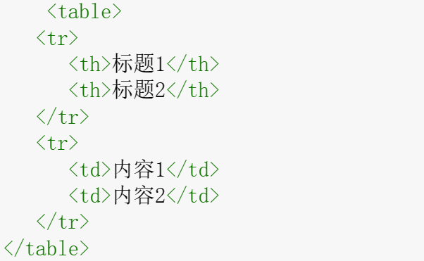

- 列表 ul, ol, li

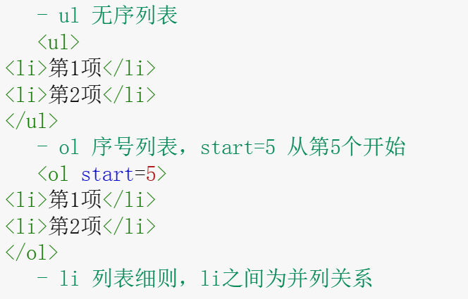

- 定义列表 dl, dt

```
- < dl>标记定义了一个定义列表，
- < dt>定义术语的标题
- < dd>定义术语的描述
```

**定义**

描述 1

描述 2

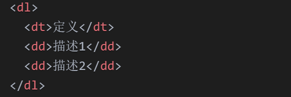

- 文本格式化

  ```
  <b>加粗；strong加粗强调
  <i>斜体；<em>斜体强调
  <cite>标记标题，斜体
  ```

- 内嵌框架

```
<iframe>用于在当前网页中嵌入另一个网页或内容。创建了一个内联框架，可在其中加载外部资源，如网页、视频、地图等。
src：指定要嵌入的内容的URL。
width 和 height：设置框架的宽度和高度。
frameborder：控制边框显示（0为无边框，1为有边框）。
allowfullscreen：允许全屏模式。
loading：设置懒加载（lazy 或 eager）。
```

- 表单 form, input, textarea, select：用户与服务器交互的最主要的渠道之一，尤其是文件上传，用户登录等场合。

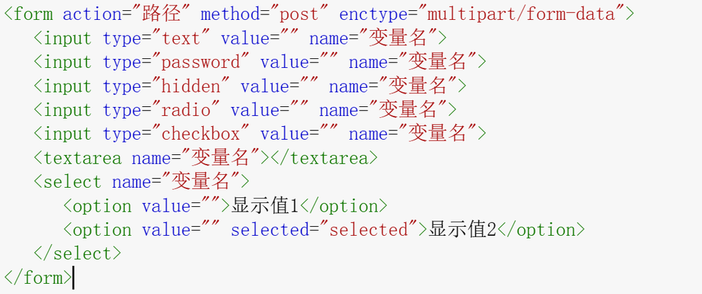

主要属性：

- id：唯一标识元素。
- class：为元素指定一个或多个类。
- title：提供元素的额外信息。
- style：定义元素的样式。
- width、height：定义元素的尺寸。

urllib 是 python 的一个获取 url(Uniform Resource Locators，统一资源定位符 )，可以用来抓取远程的网页。

- urllib.request.urlopen(url, data, timeout) 可以获取页面，获取页面内容的数据格式为 bytes 类型，需要进行 decode() 解码，转换成 str 类型。

  ```
    url : 需要打开的网址
    data : 传递的参数，字典形式，默认为None时是GET方法，data不为空时, urlopen()的提交方式为POST
    timeout : 设置网站访问的超时时间，默认可省略
    获取页面内容的数据格式为bytes类型，需要进行decode()解码，转换成str类型。
  ```

GET VS POST

- 爬虫获取数据除了 GET 方法 , 还有 POST 方法 .

  ```
    GET直接获取数据,所有访问者获得同样的数据.
    GET携带的数据要通过链接体现,拼接的过程是?变量1=值1&变量2=值2
    POST需要提交信息后获取数据(例如访问者提交查询信息后获得不同的数据)
    POST方法需要携带Data,为Dict(Json)格式
  ```

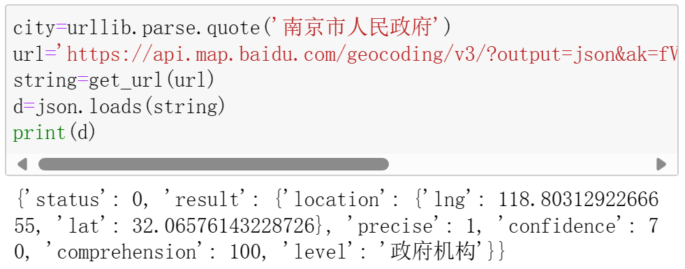

伪装为浏览器：定制网页请求信息的 header 主要属性

- 爬虫识别系统，一旦被识别为爬虫，封 IP 等方式，禁止继续访问。 - 需要针对性的做一些反爬虫策略。
- 反爬虫系统往往会根据 header 的信息判断是否为爬虫，因此可以伪装为桌面浏览器一致的信息，

  ```
    User-Agent：浏览器名与版本号等
    Host：服务器站点名
    Referer：上一页的地址
    Cookie：包含用户名登录，一些安全认证等信息
  ```

```python
from urllib import request, parse
import time
import random

#函数化处理GET
def get_url(url):
    head = {}
    head['User-Agent'] = 'Mozilla/5.0 (Windows NT 10.0; Win64; x64) \n
    AppleWebKit/537.36 (KHTML, like Gecko) Chrome/119.0.0.0 \n
    Safari/537.36'
    req = request.Request(url, headers=head)
    response = request.urlopen(req)
    html=response.read()
    string=html.decode('utf8')
    time.sleep(random.random()*2) #平均间隔1秒,避免过度查询
    return string

#函数化处理POST
def post_url(url,data):
    head = {}
    head['User-Agent'] = 'Mozilla/5.0 (Windows NT 10.0; Win64; x64) \n
    AppleWebKit/537.36 (KHTML, like Gecko) Chrome/119.0.0.0 \n
    Safari/537.36'
    data = parse.urlencode(data).encode('utf-8')
    req = request.Request(url,data=data, headers=head)
    response = request.urlopen(req)
    html=response.read()
    string=html.decode('utf-8')
    time.sleep(random.random()*2) #平均间隔1秒,避免过度查询
    return string
```